# hw9-SIR-model-simulation

Author

Kevin Cendana

### Goals

1. Simulate and analyze results
2. Write while loops in R
3. Manipulate lists in R

### Given: Step Function (not mine)

```r
step <- function(x, prob = 0.125){

  # make a slightly bigger matrix, so we don't have to worry about the boundaries.
  nr2 = nrow(x) + 2
  nc2 = ncol(x) + 2
  x2 <- matrix(0, nrow = nr2, ncol = nc2)
  infected <- which(x == 1, arr.ind = TRUE) + 1
  ni <- nrow(infected)

  directions <- c(-1, 0, 1)
  # Don't worry about cells that are already infected or removed
  for(i in directions){
    for(j in directions){
      infect_ij <- infected
      infect_ij[, "row"] <- infect_ij[, "row"] + i
      infect_ij[, "col"] <- infect_ij[, "col"] + j
      new_inf_rows <- sample(c(TRUE, FALSE), size = ni,
                        prob = c(prob, 1-prob), replace = TRUE)
      new_infect <- infect_ij[new_inf_rows, , drop = FALSE]
      x2[new_infect] <- 1
    }
  }

  # Remove the edges from the too big matrix
  result <- x2[-c(1, nr2), -c(1, nc2)]

  # Fix the cells that are already infected or removed
  result[1 <= x] <- 2
  result
}
```

### 1

Write a function to create a matrix with 1’s (infections) in all 4 corners, and 0’s everywhere else. The number of rows and number of columns should have default arguments set to 20 and 30.

```r
create_matrix <- function(rows = 20, cols = 30) {
  # create matrix filled w/ 0s (default 20 rows, 30 cols)
  mat <- matrix(0, nrow = rows, ncol = cols)

  # place 1's in each corner
  mat[1, 1] <- 1          # top-left
  mat[1, cols] <- 1       # top-right
  mat[rows, 1] <- 1       # bottom-left
  mat[rows, cols] <- 1    # bottom-right

  return(mat)
}
```

### 2

Write a function `simulate_sir` that accepts a probability of infection and an SIR matrix containing 0’s, 1’s, and 2’s, representing Susceptible, Infected, and Removed. `simulate_sir` should iterate the model until no more cells are infected, and return a list containing the following:

- number of repetition until no more cells were infected
- probability of infection (same as the argument)
- proportion of cells ultimately infected
- final SIR matrix

```r
simulate_sir <- function(infection_prob, sir_matrix) {
  # initialize the number of times to repeat
  repetition <- 0

  # loop to get rid of all infections
  while(any(sir_matrix == 1)) {
    repetition <- repetition + 1

    # call step on the current SIR matrix w/ given probability
    sir_matrix <- step(sir_matrix, prob = infection_prob)
  }

  # calculate the proportion of cells that were infected
  proportion_infected <- sum(sir_matrix == 2) / (nrow(sir_matrix) * ncol(sir_matrix))

  # return list w/ simulation results
  return(list(
    repetition = repetition,
    probability = infection_prob,
    proportion_infected = proportion_infected,
    final_matrix = sir_matrix
  ))
}
```

### 3

Starting with a 20 x 30 corner infected matrix, simulate from the above function at least 1000 times, and summarize all the resulting SIR matrices with one visualization. Which cells are most/least likely to be infected?

It should take around 10 seconds for all of these simulations to run.

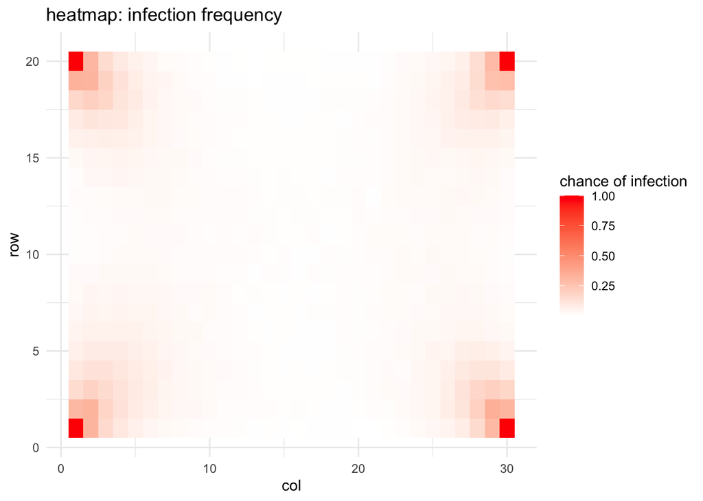

```r
library(tidyverse)
# initialize summary matrix with zeros and a random probability
 mat <- matrix(0, nrow = 20, ncol = 30)
 probability <- 0.2 # testing w/ 20% infection rate

# looping through all to run simulation
for (i in 1:1000) {
  initial_matrix <- create_matrix()
  result <- simulate_sir(infection_prob = probability, sir_matrix = initial_matrix)
  final_matrix <- result$final_matrix
   mat <-  mat + (final_matrix == 2)
}

# normalize the summary matrix to get the proportion of times each cell was infected
 mat <-  mat / 1000

# convert the matrix to a data frame in a tidy format for ggplot
summary_df <- as.data.frame(mat) %>%
  rownames_to_column('Row') %>%
  gather(key = 'Col', value = 'Frequency', -Row) %>%
  mutate(Row = as.numeric(Row),
         Col = as.numeric(sub("V", "", Col)))

# create heat map
ggplot(summary_df, aes(x = Col, y = Row, fill = Frequency)) +
  geom_tile() +
  scale_fill_gradient(low = "white", high = "red") +
  theme_minimal() +
  labs(title = "heatmap: infection frequency", x = "col", y = "row", fill = "chance of infection")
```

### 4

(Intentionally open ended)

Simulate using `simulate_sir` at least 1000 times while varying the probability of infection and create a data frame with one row for every simulation, containing at least the following columns:

- number of repetition until no more cells were infected
- probability of infection
- proportion of cells ultimately infected

How do these variables appear to be related? Visualize the relationship between them.

[figure not shown]

```r
library(tidyverse)

# define infection prob & number of simulations for each prob
prob_range <- seq(0.01, 0.5, by = 0.1)
num_simulations <- 1000

# initialize empty list to store results
simulation_results_list <- list()

# loop through each probability in range
for (prob in prob_range) {
  for (idx in 1:num_simulations) {
    initial_matrix <- create_matrix()  # create matrix w/ infected corners
    result <- simulate_sir(prob, initial_matrix)  # infect matrix

    # store results in list
    simulation_results_list[[length(simulation_results_list) + 1]] <- c(result$repetition, prob, result$proportion_infected)
  }
}

# convert the results into proper data frame to be displayed
simulation_results <- do.call(rbind, simulation_results_list)
colnames(simulation_results) <- c("repetition", "infection_prob", "infection_prop")
simulation_results <- as.data.frame(simulation_results)
simulation_results <- na.omit(simulation_results)

# plot
# geom_jitter adds random noise to spread out points (was overplotted)
ggplot(simulation_results, aes(x = infection_prob, y = infection_prop)) +
  geom_point(aes(color = as.factor(repetition)), alpha = 0.6, size = 1.5) +
  theme_minimal() +
  labs(title = "infection probability vs. proportion",
       x = "infection proportion",
       y = "infection proportion",
       caption = "darker colors = fewer repetitions & faster infection") +
  xlim(0, 1) + ylim(0, 1) +
  scale_color_viridis_d(guide = 'none') # remove legend
```